# CardioGoodFitness-Mora

#### TM498 Analysis

```python
data = pd.read_csv('CardioGoodFitness.csv') # re-read dataframe
data.drop(indexTM498,inplace=True) # keep rows that include TM498
```

```python
round(data.describe()) # rounding for convenience
```

|  | Age | Education | Usage | Fitness | Income | Miles |
| --- | --- | --- | --- | --- | --- | --- |
| count | 60.0 | 60.0 | 60.0 | 60.0 | 60.0 | 60.0 |
| mean | 29.0 | 15.0 | 3.0 | 3.0 | 48974.0 | 88.0 |
| std | 7.0 | 1.0 | 1.0 | 1.0 | 8654.0 | 33.0 |
| min | 19.0 | 12.0 | 2.0 | 1.0 | 31836.0 | 21.0 |
| 25% | 24.0 | 14.0 | 3.0 | 3.0 | 44912.0 | 64.0 |
| 50% | 26.0 | 16.0 | 3.0 | 3.0 | 49460.0 | 85.0 |
| 75% | 33.0 | 16.0 | 3.0 | 3.0 | 53439.0 | 106.0 |
| max | 48.0 | 18.0 | 5.0 | 4.0 | 67083.0 | 212.0 |

```python
data.info()
```

```
<class 'pandas.core.frame.DataFrame'>
Int64Index: 60 entries, 80 to 139
Data columns (total 9 columns):
 #   Column         Non-Null Count  Dtype
---  ------         --------------  -----
 0   Product        60 non-null     object
 1   Age            60 non-null     int64
 2   Gender         60 non-null     object
 3   Education      60 non-null     int64
 4   MaritalStatus  60 non-null     object
 5   Usage          60 non-null     int64
 6   Fitness        60 non-null     int64
 7   Income         60 non-null     int64
 8   Miles          60 non-null     int64
dtypes: int64(6), object(3)
memory usage: 4.7+ KB
```

```python
# Print the Mean Absolute Deviation
print(data.mad())
```

```
Age             5.660000
Education       1.105000
Usage           0.566667
Fitness         0.423333
Income       6753.050000
Miles          23.762222
dtype: float64
```

```python
print(data.value_counts("Product"),"\n\n",data.value_counts("Gender"),"\n\n",data.value_counts("MaritalStatus"))
```

```
Product
TM498    60
dtype: int64

 Gender
Male      31
Female    29
dtype: int64

 MaritalStatus
Partnered    36
Single       24
dtype: int64
```

Brief Summary:  
TM498 is the second most used product  
Gender is almost a 50/50 split  
Most customers are partnered

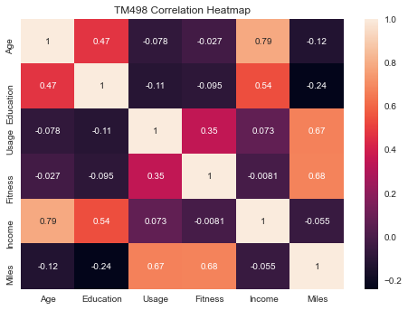

```python
sns.heatmap(data.corr(), annot=True)  # plot the correlation coefficients as a heatmap
plt.title("TM498 Correlation Heatmap")
plt.show()
```

### Three correlation coefficients are >0.6

### Age - Income, Usage - Miles, Fitness - Miles

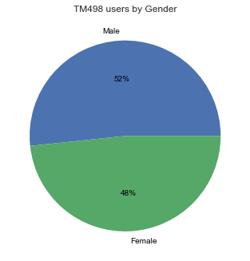

```python
GenLbl = data.value_counts("Gender").index
plt.style.available # what styles are available to enhance graph quality?
plt.style.use('seaborn') # style selected

# create a pie chart of male v. female customers
# use pandas value counts method
plt.pie(data.value_counts("Gender"), radius=1,autopct='%1.0f%%', labels=GenLbl, textprops=dict(color="black"))
plt.title("TM498 users by Gender")
plt.show()
```

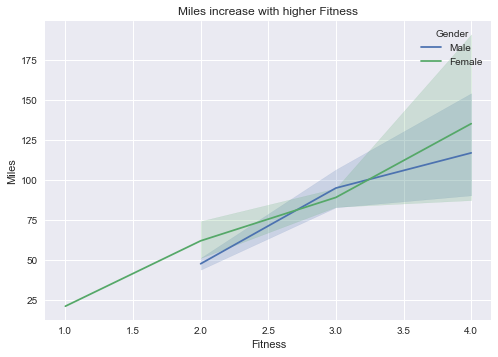

```python
# The miles intended increase with higher fitness

sns.lineplot(x=data.Fitness,y=data.Miles, hue=data.Gender)
plt.title("Miles increase with higher Fitness")
plt.show()
```

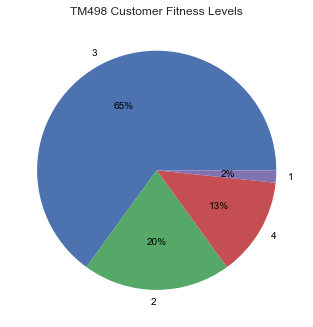

```python
# create a pie chart of male v. female customers
# use pandas value counts method
Lbl = data.value_counts("Fitness").index
plt.pie(data.value_counts("Fitness"), radius=1,autopct='%1.0f%%', labels=Lbl, textprops=dict(color="black"))
plt.title("TM498 Customer Fitness Levels")
plt.show()
```

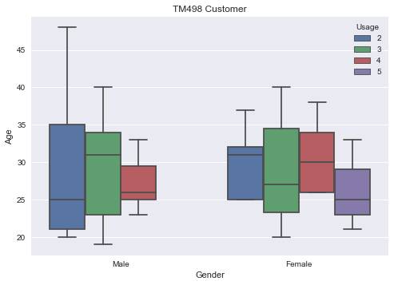

```python
# multi-variate analysis step
# Age, Gender, Marital Status

sns.boxplot(hue=data['Usage'], y=data['Age'], x=data['Gender']) #
plt.title("TM498 Customer")
plt.show()
#print('Partnered customers have a higher median age than single customers, regardless of gender')
```

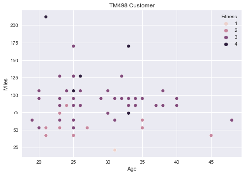

```python
sns.scatterplot(y=data['Miles'], x=data['Age'], hue=data['Fitness']) #
plt.title("TM498 Customer")
plt.show()
```

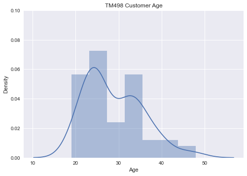

```python
sns.distplot(data['Age'])
plt.title("TM498 Customer Age")
plt.ylim(0,0.1)
plt.show()
```

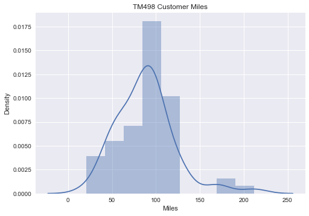

```python
sns.distplot(data['Miles'])
plt.title("TM498 Customer Miles")
plt.show()
```

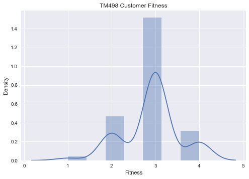

```python
sns.distplot(data['Fitness'])
plt.title("TM498 Customer Fitness")
plt.show()
```

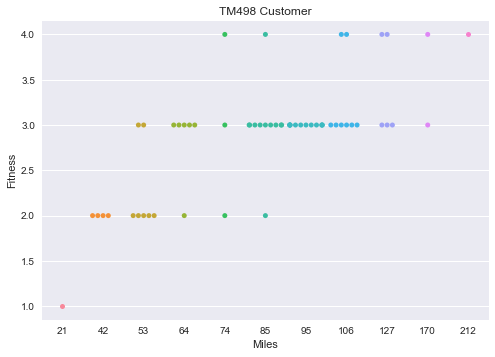

```python
sns.swarmplot(data['Miles'], data['Fitness'])
plt.title("TM498 Customer")
plt.show()
```

**TM498 conclusions**

[output not shown]

Overall, there are many similarities TM195 product relationships

#### TM798 Analysis

```python
# re-read data file
data = pd.read_csv('CardioGoodFitness.csv')
data.drop(indexTM798,inplace=True) # drop all rows where Product != TM798
```

```python
round(data.describe()) # summary description for the dataframe
```

|  | Age | Education | Usage | Fitness | Income | Miles |
| --- | --- | --- | --- | --- | --- | --- |
| count | 40.0 | 40.0 | 40.0 | 40.0 | 40.0 | 40.0 |
| mean | 29.0 | 17.0 | 5.0 | 5.0 | 75442.0 | 167.0 |
| std | 7.0 | 2.0 | 1.0 | 1.0 | 18506.0 | 60.0 |
| min | 22.0 | 14.0 | 3.0 | 3.0 | 48556.0 | 80.0 |
| 25% | 25.0 | 16.0 | 4.0 | 4.0 | 58205.0 | 120.0 |
| 50% | 27.0 | 18.0 | 5.0 | 5.0 | 76568.0 | 160.0 |
| 75% | 30.0 | 18.0 | 5.0 | 5.0 | 90886.0 | 200.0 |
| max | 48.0 | 21.0 | 7.0 | 5.0 | 104581.0 | 360.0 |

```python
data.info() # checking variable data types
```

```
<class 'pandas.core.frame.DataFrame'>
Int64Index: 40 entries, 140 to 179
Data columns (total 9 columns):
 #   Column         Non-Null Count  Dtype
---  ------         --------------  -----
 0   Product        40 non-null     object
 1   Age            40 non-null     int64
 2   Gender         40 non-null     object
 3   Education      40 non-null     int64
 4   MaritalStatus  40 non-null     object
 5   Usage          40 non-null     int64
 6   Fitness        40 non-null     int64
 7   Income         40 non-null     int64
 8   Miles          40 non-null     int64
dtypes: int64(6), object(3)
memory usage: 3.1+ KB
```

```python
# Print the Mean Absolute Deviation
print(data.mad())
```

```
Age              5.23500
Education        1.32625
Usage            0.78625
Fitness          0.54375
Income       16509.99625
Miles           44.29000
dtype: float64
```

```python
#select_dtypes()- returns a subset of the dataframe based on the data types that are provided in the 'include' parameter.
numerical_features = data.select_dtypes(include=["int64","float64"])
numerical_features.columns
```

```
Index(['Age', 'Education', 'Usage', 'Fitness', 'Income', 'Miles'], dtype='object')
```

```python
skewed_features = numerical_features.apply(lambda x : skew(x.dropna())).sort_values(ascending=False)
skewed_features
```

```
Age          1.393574
Miles        1.091055
Usage        0.644064
Education    0.386095
Income      -0.076628
Fitness     -1.514558
dtype: float64
```

```python
skewness=skewed_features[abs(skewed_features)>0.7]

print ("There are {} highly skewed numerical features.".format(skewness.shape[0]))
print(skewness)
```

```
There are 3 highly skewed numerical features.
Age        1.393574
Miles      1.091055
Fitness   -1.514558
dtype: float64
```

**Summarize the Objects**

```python
print(data.value_counts("Product"),"\n\n",data.value_counts("Gender"),"\n\n",data.value_counts("MaritalStatus"))
```

```
Product
TM798    40
dtype: int64

 Gender
Male      33
Female     7
dtype: int64

 MaritalStatus
Partnered    23
Single       17
dtype: int64
```

Brief Summary:  
TM798 customers have the smallest population in the data set, only half of the TM195 customers The majority are Male customers. More than half of Customers are Partnered

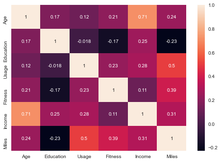

```python
sns.heatmap(data.corr(), annot=True)  # plot the correlation coefficients as a heatmap
# look more specifically at relationships with coeff > 0.6
```

**The highest relevant correlation for TM798 is Age and Income**

```python
 # create labels for a chart
GenLbl = data.value_counts("Gender").index
plt.style.available # what styles are available to enhance graph quality?
plt.style.use('seaborn') # style selected
```

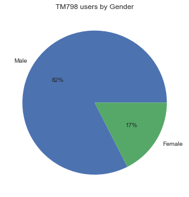

```python
# create a pie chart of male v. female customers
# annotate chart for use in powerpoint report

plt.pie(data.value_counts("Gender"), radius=1,autopct='%1.0f%%', labels=GenLbl)
plt.title("TM798 users by Gender")
plt.show()
```

```python
# try saving the image for insert into my report
# plt.savefig('TM798_Pie.jpg', bbox_inches='tight')
```

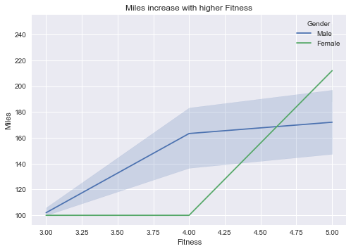

```python
# The miles intended increase with higher fitness

sns.lineplot(x=data.Fitness,y=data.Miles, hue=data.Gender)
plt.title("Miles increase with higher Fitness")
plt.show()
```

#### Continue multi-variate analysis trying different visualizations

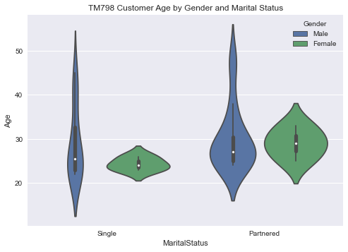

```python
# multi-variate analysis step
# Age, Gender, Marital Status

sns.violinplot(data['MaritalStatus'], data['Age'], hue=data['Gender']) #, hue=data['Usage'])
plt.title("TM798 Customer Age by Gender and Marital Status")
plt.show()
```

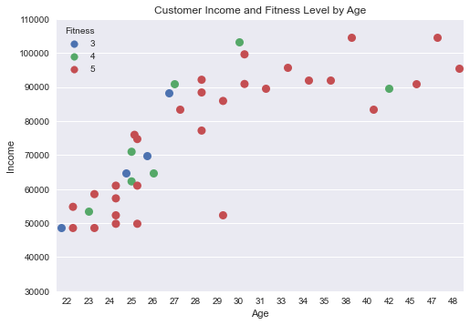

```python
# Visualizing Income by Age and Fitness
sns.swarmplot( data['Age'], data['Income'], hue=data['Fitness'], size=9, dodge=True)
plt.title("Customer Income and Fitness Level by Age")
plt.ylim(30000,110000)
#plt.xlim(18,50)
plt.show()
```

```
TM798 Customer Income versus Education
```

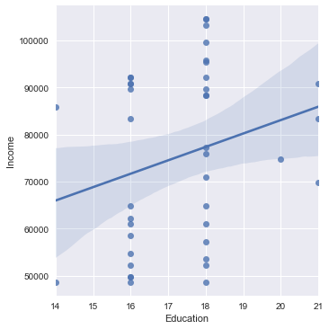

```python
sns.lmplot(y="Income", x="Education", data=data) # linear regression model
print("TM798 Customer Income versus Education")
plt.show()
```

```
TM798 Customer Fitness versus Income
```

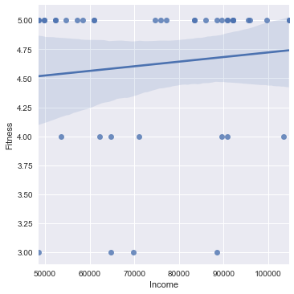

```python
sns.lmplot(y="Fitness", x="Income", data=data) # linear regression model
print("TM798 Customer Fitness versus Income")
plt.show()
```

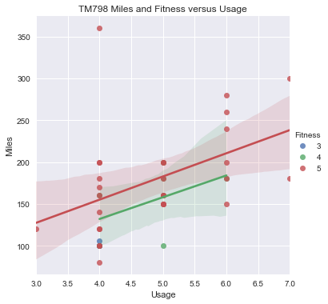

```python
sns.lmplot(x="Usage", y="Miles", data=data, hue="Fitness")
plt.title("TM798 Miles and Fitness versus Usage")
plt.show()
```

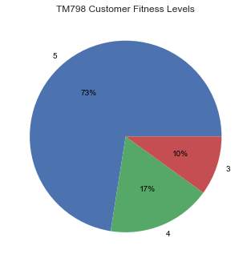

```python
# create a pie chart of male v. female customers
# use pandas value counts method
Lbl = data.value_counts("Fitness").index
plt.pie(data.value_counts("Fitness"), radius=1,autopct='%1.0f%%', labels=Lbl, textprops=dict(color="black"))
plt.title("TM798 Customer Fitness Levels")
plt.show()
```

```python
round(data.describe(),0)
```

|  | Age | Education | Usage | Fitness | Income | Miles |
| --- | --- | --- | --- | --- | --- | --- |
| count | 40.0 | 40.0 | 40.0 | 40.0 | 40.0 | 40.0 |
| mean | 29.0 | 17.0 | 5.0 | 5.0 | 75442.0 | 167.0 |
| std | 7.0 | 2.0 | 1.0 | 1.0 | 18506.0 | 60.0 |
| min | 22.0 | 14.0 | 3.0 | 3.0 | 48556.0 | 80.0 |
| 25% | 25.0 | 16.0 | 4.0 | 4.0 | 58205.0 | 120.0 |
| 50% | 27.0 | 18.0 | 5.0 | 5.0 | 76568.0 | 160.0 |
| 75% | 30.0 | 18.0 | 5.0 | 5.0 | 90886.0 | 200.0 |
| max | 48.0 | 21.0 | 7.0 | 5.0 | 104581.0 | 360.0 |

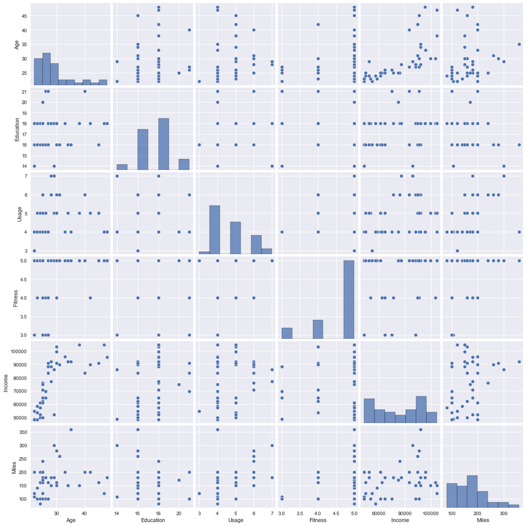

```python
sns.pairplot(data)
plt.show()
```

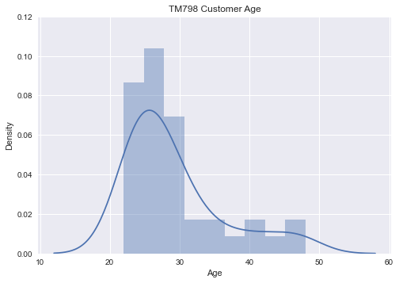

```python
sns.distplot(data['Age'])
plt.title("TM798 Customer Age")
plt.ylim(0,0.12)
plt.show()
```

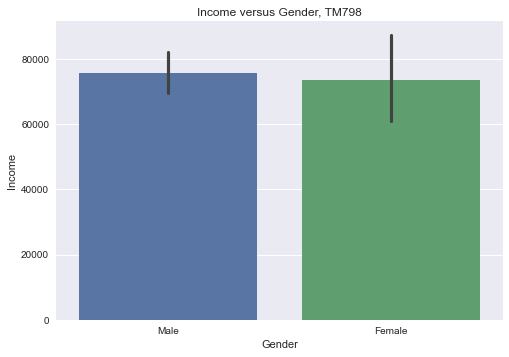

```python
sns.barplot(x=data.Gender, y=data.Income)
plt.title("Income versus Gender, TM798")
plt.show()
```

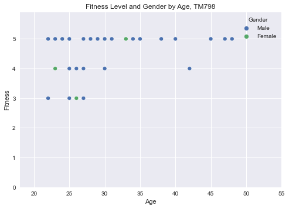

```python
sns.scatterplot(x=data.Age, y=data.Fitness, hue=data.Gender)
plt.title("Fitness Level and Gender by Age, TM798")
plt.ylim(0,5.9)
plt.xlim(18,55)
plt.show()
```

**TM798 conclusions**

```
- Gender use is heavily dominated by males; very few females<br>
- Most customers are partnered and under 30 years of age<br>
- No customers report a fitness level below 3<br>
- Most customers are level 4 or level 5 fitness<br>
- The median age is 27 years for TM798 customers<br>
- Age and Income are positively correlated<br>
```

Overall, the TM798 customer base is the smallest in number of customers, and the highest fitness levels and income

#### Additional Conclusions

**TM195**

```
- most used product model with customers in each of the five fitness levels<br>
- largely centered around fitness level 3<br>
- customers are late 20s and partnered<br>
- customer median income levels are below 50K<br><br>
```

TM498

```
- ranks second in product usage<br>
- largely centered around fitness level 3<br>
- customers are late 20s and partnered<br>
- customer median income levels are below 70K<br><br>
```

TM798

[output not shown]

#### Project Conclusions

My personal insight from this exercise is that analyzing the project data became an interesting iterative exercise.  
Trying different visualizations was very helpful. Forcing myself to investigate and then describe or summarize the relationships between variables often led to new questions about other relationships, and more iteration. So, I feel there are many more aspects to investigate. There are also likely much more efficient ways of coding. Very interesting!